# Protein structure-based homology and machine learning

Scripts to reproduce figures and tables in manuscript GIGA-D-18-00288

Brendan R.E. Ansell

10/16/2018

# Data import

Read in data sets for BLAST annotation, PFAM annotation and I-TASSER output metrics

```r
GeneDesc <- read_tsv("../data/GiardiaDB-39_GintestinalisAssemblageA_AnnotatedProteins.description",
                     col_names = FALSE, col_types = cols())
names(GeneDesc) <- c('GeneID','Description')
metrics_df <- read.delim("../data/metrics_clean.txt",sep="\t", stringsAsFactors = FALSE, quote="", header=TRUE)
mismatch_BLAST <- read_tsv("../data/mismatches_BLAST.tsv", col_types = cols())
PDB_pfam <- read_tsv("../data/hmmer_pdb_all.txt", col_types = cols())  #accessed in Oct 2017
PDB_pfam <- PDB_pfam %>% mutate(code_chain=paste0(PDB_ID,CHAIN_ID)) %>%
            separate(PFAM_ACC, into=c('PFAMpref','PFAMsuff'))
###Giardia PFAM domains
#GDB_IPS <- read_tsv("http://giardiadb.org/common/downloads/release-39/GintestinalisAssemblageAWB/txt/GiardiaDB-39_GintestinalisAssemblageAWB_InterproDomains.txt", col_names = FALSE)
GDB_IPS <- read_tsv("../data/GiardiaDB-39_GintestinalisAssemblageAWB_InterproDomains.txt",
                    col_types = cols(), col_names = FALSE)
names(GDB_IPS) <- c('GeneID','source','InterproID','Desc','GDBpfam_start','GDBpfam_end','eVal')
GDB_pfam <- GDB_IPS %>% filter(str_detect(InterproID,'^PF')) %>%
  dplyr::rename(PFAMpref=InterproID) %>% distinct()
PFAM_descriptionTable <- read_tsv("../data/PFAM_descriptionMapping.tsv",col_names = TRUE, col_types = cols())
```

## Compute additional metrics

Metrics derived from I-TASSER output: sd of secondary structure predictions, and query:reference length ratio.

```r
metrics_all <- metrics_df %>%
  mutate(lenRatio=seq.ssLen/PDB_AA) %>%
  mutate(Hprop=nHrc/seq.ssLen,
                      Eprop=nErc/seq.ssLen,
                      Cprop=nCrc/seq.ssLen) %>%
  rowwise() %>% mutate(SS_sd = sd(c(Hprop, Eprop, Cprop)))
```

# Check positive controls

## SFigure 1

Investigate discordant reference structure matches for *Giardia* peptides encoding solved structures

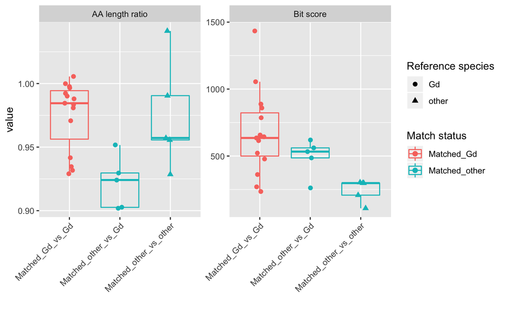

```r
mismatch_BLAST_status <- mismatch_BLAST %>%
  mutate(matchStatus = factor(case_when(str_detect(status,'miss') ~ 'Matched_other',
                                   str_detect(status,'hit') ~ 'Matched_Gd'))) %>%
  mutate(refSpecies = factor(case_when(str_detect(status,'hit') ~ 'Gd',
                                       str_detect(status,'non-Giardia') ~ 'other',
                                       TRUE ~ 'Gd'))) %>%
  select(GeneID, matchStatus,refSpecies,Ref_Query_AAlenRatio,bit_score)

mismatch_BLAST_status %>%
  rename(`Reference species` = refSpecies,
         `Match status` = matchStatus,
         `AA length ratio` = Ref_Query_AAlenRatio,
         'Bit score' = bit_score) %>%
  gather(key,value,-c(GeneID,`Match status`,`Reference species`)) %>%
  mutate(xSep=paste0(`Match status`,'_vs_',`Reference species`)) %>%
  ggplot(aes(x=xSep, y=value)) +
  geom_boxplot(aes(col=`Match status`), alpha=0) +
  geom_jitter(aes(col=`Match status`,shape=`Reference species`), width=0.1, size=2) +
  facet_wrap(~ key, scales="free")   +
  theme(axis.text.x = element_text(angle=45,hjust=1)) +
  xlab("")
ggsave("../results/SF1.pdf",width=8,height=4)
```

Test differences in BLAST bit scores, and query:reference AA length ratios

```r
mismatch_BLAST_forTest <- mismatch_BLAST_status %>% unite(match_species, c(matchStatus,refSpecies))
#Test differences in Ref_Query_AAlenRatio
aov_lenRat.res <- aov(Ref_Query_AAlenRatio ~ match_species, data = mismatch_BLAST_forTest )
summary(aov_lenRat.res)
```

```
              Df  Sum Sq  Mean Sq F value  Pr(>F)
match_species  2 0.01126 0.005628    6.39 0.00649 **
Residuals     22 0.01938 0.000881
---
Signif. codes:  0 ‘***’ 0.001 ‘**’ 0.01 ‘*’ 0.05 ‘.’ 0.1 ‘ ’ 1
```

```r
#Multiple pair-wise comparisons
TukeyHSD(aov_lenRat.res)
```

```
  Tukey multiple comparisons of means
    95% family-wise confidence level

Fit: aov(formula = Ref_Query_AAlenRatio ~ match_species, data = mismatch_BLAST_forTest)

$match_species
                                           diff          lwr         upr     p adj
Matched_other_Gd-Matched_Gd_Gd       -0.0531666 -0.091663990 -0.01466921 0.0059271
Matched_other_other-Matched_Gd_Gd    -0.0004910 -0.038988390  0.03800639 0.9994342
Matched_other_other-Matched_other_Gd  0.0526756  0.005526119  0.09982508 0.0267095
```

```r
#Test differences in bit_score
aov_bitScore.res <- aov(bit_score ~ match_species, data = mismatch_BLAST_forTest )
summary(aov_bitScore.res)
```

```
              Df  Sum Sq Mean Sq F value Pr(>F)
match_species  2  708405  354202   5.403 0.0123 *
Residuals     22 1442156   65553
---
Signif. codes:  0 ‘***’ 0.001 ‘**’ 0.01 ‘*’ 0.05 ‘.’ 0.1 ‘ ’ 1
```

```r
#Multiple pair-wise comparisons
TukeyHSD(aov_bitScore.res)
```

```
  Tukey multiple comparisons of means
    95% family-wise confidence level

Fit: aov(formula = bit_score ~ match_species, data = mismatch_BLAST_forTest)

$match_species
                                       diff       lwr       upr     p adj
Matched_other_Gd-Matched_Gd_Gd       -179.2 -511.3312 152.93122 0.3808485
Matched_other_other-Matched_Gd_Gd    -428.2 -760.3312 -96.06878 0.0101240
Matched_other_other-Matched_other_Gd -249.0 -655.7760 157.77601 0.2933180
```

# PFAM code matching

Join PFAM annotation databases and identify query:reference pairs with at least 1 matching PFAM code.  
Annotation: PFAM codes assigned to Giardia query peptides: ‘GDB_pfam’  
PFAM codes assigned to peptides encoding PDB reference structures: ‘PDB_pfam’.

```r
metrics_long <- metrics_all %>%
  mutate(code_chain=toupper(codechain)) %>%
  left_join(GDB_pfam,by="GeneID") %>% rename(GDB_PFAMpref=PFAMpref) %>%
  left_join(PDB_pfam,by="code_chain") %>% rename(PDB_PFAMpref=PFAMpref) %>%
  distinct() %>% rename(GDB_PFAM_desc = Desc, PDB_PFAM_desc = PFAM_desc)
```

Plot number of PFAM domains per query:reference pair

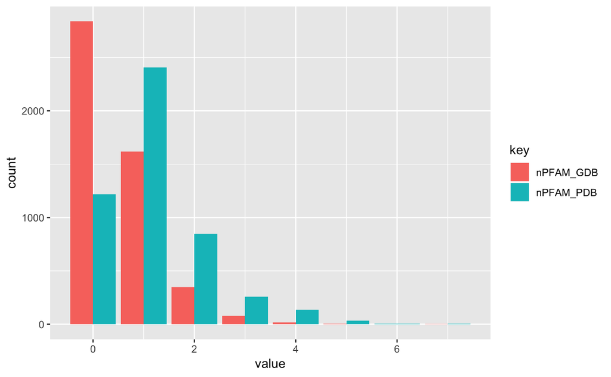

```r
nPFAM_Q_R <- metrics_long %>%
  select(GeneID, GDB_PFAMpref, PDB_PFAMpref) %>%
  distinct() %>%
  group_by(GeneID) %>%
  summarize_at(vars(GDB_PFAMpref, PDB_PFAMpref), funs( . %>% na.omit() %>% n_distinct )) %>%
  rename(nPFAM_GDB = GDB_PFAMpref, nPFAM_PDB = PDB_PFAMpref )
nPFAM_Q_R %>% gather(key,value,-GeneID) %>% ggplot(aes(value)) +
  geom_bar(aes(fill=key), position="dodge", show.legend = TRUE)
```

Calculate n. matching domains

```r
#Because all pairwise combinations of PFAM domains are listed, need only filter for exact match:
nMatch_count <- metrics_long %>%
  select(GeneID,code,chain,code_chain,GDB_PFAMpref,PDB_PFAMpref) %>%
  distinct() %>%
  group_by(GeneID) %>%
  filter(GDB_PFAMpref==PDB_PFAMpref) %>%
  summarize(n_Match = n())

nMatch <- metrics_all[ , "GeneID"] %>%
  left_join(nMatch_count, by="GeneID") %>%
  mutate(n_Match = ifelse(is.na(n_Match), 0 ,n_Match))
```

Summarize PFAM matches across annotation groups

```r
metrics_nMatch <- metrics_all %>%
  left_join(nPFAM_Q_R, by="GeneID") %>%
  left_join(nMatch,by="GeneID") %>%
   mutate(n_Match=ifelse(is.na(n_Match), 0, n_Match)) %>%
   mutate(matchStatus=ifelse(n_Match==0,'noMatch','exactMatch')) %>%
   left_join(GeneDesc,by="GeneID") %>% select(GeneID,Description,everything()) %>%
   mutate(descBin = ifelse(str_detect(Description,'hypothetical') | str_detect(Description,'Hypothetical'), 'Hyp','Annot'))
```

```r
metrics_nMatch %>% count(descBin,matchStatus)
```

| descBin | matchStatus | n |
| --- | --- | --- |
| Annot | exactMatch | 883 |
| Annot | noMatch | 767 |
| Hyp | exactMatch | 212 |
| Hyp | noMatch | 3039 |

## SFigure 2

Relative peptide length and number of matching PFAM domains.

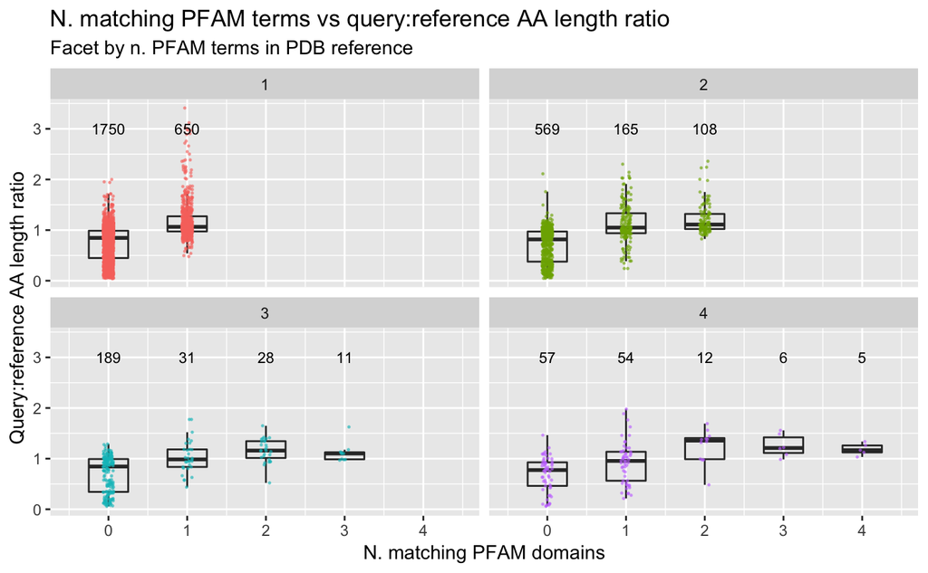

```r
lenRatio_X_nMatch <- metrics_nMatch %>%
  select(GeneID, Cov, GDB_AA, lenRatio, contains('nPFAM'),n_Match, descBin) %>%
  mutate(`n_Match:nPFAM_PDB` = n_Match/nPFAM_PDB) %>%
  na.omit() %>%
  group_by(n_Match, nPFAM_PDB) %>% summarize(median_lenRatio = median(lenRatio),
                                                mean_lenRatio = mean(lenRatio),
                                                mean_GDB_AAlen = mean(GDB_AA),
                                                median_GDB_AAlen = median(GDB_AA),
                                             group_size = n()) %>%
  arrange(n_Match, nPFAM_PDB, desc(group_size))
metrics_nMatch %>%
  filter(nPFAM_PDB<=4) %>% #filter(n_Match==0) %>%
  filter(nPFAM_PDB>0) %>%
  ggplot() +
  geom_boxplot(aes(x=n_Match , y=lenRatio, group=factor(n_Match)), alpha=0, width=0.5)+
  geom_jitter(aes(x=n_Match , y=lenRatio, col=factor(nPFAM_PDB),
                  group=factor(nPFAM_PDB)),
                  position=position_jitterdodge(dodge.width = 0.85), alpha=0.5, cex=0.25) +
  geom_text(data=lenRatio_X_nMatch %>%
              filter(n_Match<=4, nPFAM_PDB<=4),
            aes(x=n_Match, y=3, label=group_size, group=nPFAM_PDB), size=3) +
  facet_wrap( ~ nPFAM_PDB) +
  theme(legend.position = "none") +
  ggtitle("N. matching PFAM terms vs query:reference AA length ratio",
          subtitle="Facet by n. PFAM terms in PDB reference") +
  xlab("N. matching PFAM domains") + ylab("Query:reference AA length ratio")
ggsave("../results/SF2.pdf",width=6,height=6)
```

## Figure 2a

Plot intersection of BLAST annotation status and PFAM code annotations.

```r
source("upset.R")
upSets <- metrics_nMatch %>% select(GeneID, descBin, nPFAM_GDB, nPFAM_PDB, n_Match) %>%
  mutate_at(vars(-GeneID, -descBin) , funs(binary = ifelse(. > 0, 1, 0))) %>%
  mutate(descCategory = ifelse(descBin=="Hyp",1,2)) %>%
  distinct() %>% select(GeneID, descCategory, contains('binary')) %>%
  rename(Query = nPFAM_GDB_binary, Reference = nPFAM_PDB_binary, Match = n_Match_binary)
upSets %>% count(descCategory, Query, Reference, Match)
```

| descCategory | Query | Reference | Match | n |
| --- | --- | --- | --- | --- |
| 1 | 0 | 0 | 0 | 792 |
| 1 | 0 | 1 | 0 | 1848 |
| 1 | 1 | 0 | 0 | 118 |
| 1 | 1 | 1 | 0 | 281 |
| 1 | 1 | 1 | 1 | 212 |
| 2 | 0 | 0 | 0 | 32 |
| 2 | 0 | 1 | 0 | 166 |
| 2 | 1 | 0 | 0 | 274 |
| 2 | 1 | 1 | 0 | 295 |
| 2 | 1 | 1 | 1 | 883 |

```r
annotStatus <- function(row, min, max){
  newData <- (row["descCategory"] <= max) & (row["descCategory"] > min)}
upset(data.frame(upSets),
      sets=c('Query','Reference','Match'),
      main.bar.color = 'black',
      queries = list(list(query = annotStatus, params = list(1,2),
                          color="light blue",active=TRUE)), point.size=3)
```

```r
pdf("../results/F2a.pdf", width = 4,height=3, onefile = FALSE) #works..ish
#pdf("../results/F2a.pdf", width = 4.5,height=3.5, onefile = FALSE)
upset(data.frame(upSets),
      sets=c('Query','Reference','Match'),
      main.bar.color = 'black',
      queries = list(list(query = annotStatus, params = list(1,2),
                          color="light blue",active=TRUE)), point.size=3)
```

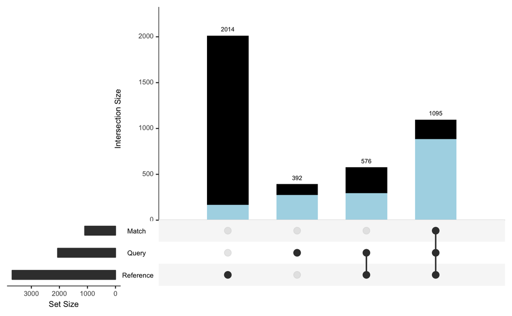

```r
dev.off()
```

## Figure 2b

PFAM term enrichment testing

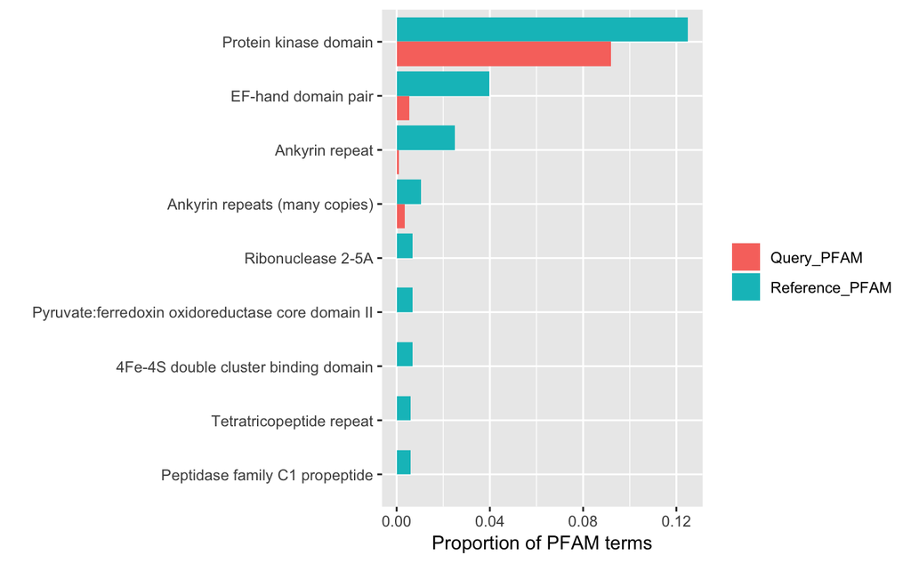

```r
source("rowwise_fisher.R")
matchStatus_PFAMcounts <- metrics_long %>%
  left_join(metrics_nMatch %>% select(GeneID, matchStatus), by="GeneID") %>%
  dplyr::select(1,lenRatio, matchStatus, GDB_PFAMpref,PDB_PFAMpref) %>%
  gather(key=DB,value=PFAM,-c(GeneID,matchStatus,lenRatio)) %>%
  na.omit() %>%
  filter(lenRatio >0.9 & lenRatio <1.1) %>% ungroup() %>%
  count(matchStatus,DB,PFAM) %>%
  spread(key=DB, value=n, fill = 0)
#set up parameters for Fisher tables
myStatus <- "exactMatch"
minFreq <- 3
Foreground <- 'PDB_PFAMpref'
background <- 'GDB_PFAMpref'
termSums <- matchStatus_PFAMcounts %>%
  filter(get(Foreground) >= minFreq) %>%
  filter(matchStatus == myStatus) %>%
  summarize(allForeground = sum(get(Foreground)),
            allBackground = sum(get(background)),
            allTerms = sum(get(Foreground),get(background))) %>% unlist()
Fisher_df <- matchStatus_PFAMcounts %>%
  filter(matchStatus==myStatus) %>%
  dplyr::rename(Foreground = PDB_PFAMpref,
                BACKGROUND = GDB_PFAMpref) %>%
  rowwise() %>%
  mutate(sumTerm=sum(Foreground,BACKGROUND),
         allForeground=termSums[[1]],
         allBackground=termSums[[2]],
         allTerms=termSums[[3]]) %>%
  mutate('a' = Foreground,
         'b' = sumTerm - Foreground,
         'c' = allForeground - Foreground,
         'd' = allTerms - allForeground - b) %>%
  dplyr::select(PFAM,Foreground,BACKGROUND,everything()) %>%
  ungroup()
mydata <- Fisher_df
p <- t(apply(mydata %>%
               dplyr::select(a,b,c,d) %>%
               filter(a >= minFreq), 1, row_fisher))
results <- cbind(mydata %>% filter(a >= minFreq) %>%
                   dplyr::select(1:7), p) %>%
#1:7 as no background of repressed, lowly transcribed (<0.85 percentile; i.e., the equivalent of the nonDTG set), is included.
  arrange(p_val) %>%
  mutate(adjP=p.adjust(.$p_val, method="BH" ))  #correction for multiple comparisons
#No significant enrichment
results %>% filter(p_val < 0.05) %>%
  arrange(p_val) %>%
  filter(matchStatus=='exactMatch') %>%
  mutate(`Reference_PFAM` = Foreground/allForeground,
         `Query_PFAM` = BACKGROUND/allBackground) %>%
  left_join(PDB_pfam %>% select(PFAMpref,PFAM_Name,PFAM_desc), by=c("PFAM" = "PFAMpref")) %>%
  distinct() %>%
  dplyr::select(Foreground,BACKGROUND, PFAM,PFAM_desc,Query_PFAM,Reference_PFAM) %>%
  filter(Foreground >= 7) %>% select(-c(Foreground,BACKGROUND)) %>%
  gather(key,value,-c(PFAM,PFAM_desc)) %>%
  ggplot(aes(x=reorder(PFAM_desc,value,FUN=max),y=value,fill=key)) +
  geom_bar(stat="identity",position="dodge", show.legend = TRUE) +
  coord_flip() +
  xlab("") + ylab("Proportion of PFAM terms") +
  labs(fill="")
ggsave("../results/F2b.pdf",width=8,height=3.5)
```

## Check putative additional domains in NEK kinases

EF hand domains in NEK kinases

```r
metrics_nMatch %>% filter(n_Match > 0, str_detect(Description,"NEK")) %>%
  filter(nPFAM_PDB > n_Match) %>%
  filter(code=="3HX4") %>%
  left_join(metrics_long,by="GeneID") %>%
  select(GeneID, n_Match, contains("PFAMpref"), contains("PFAM_desc")) %>%
  distinct() %>%
  filter(PDB_PFAMpref=="PF13499")
```

| GeneID | n_Match | GDB_PFAMpref | PDB_PFAMpref | GDB_PFAM_desc | PDB_PFAM_desc |
| --- | --- | --- | --- | --- | --- |
| GL50803_137728 | 1 | PF00069 | PF13499 | Pkinase | EF-hand domain pair |
| GL50803_137742 | 1 | PF12796 | PF13499 | Ank_2 | EF-hand domain pair |
| GL50803_137742 | 1 | PF00069 | PF13499 | Pkinase | EF-hand domain pair |
| GL50803_137743 | 1 | PF12796 | PF13499 | Ank_2 | EF-hand domain pair |
| GL50803_137743 | 1 | PF00069 | PF13499 | Pkinase | EF-hand domain pair |
| GL50803_15035 | 1 | PF00069 | PF13499 | Pkinase | EF-hand domain pair |
| GL50803_15035 | 1 | PF12796 | PF13499 | Ank_2 | EF-hand domain pair |
| GL50803_24400 | 1 | PF12796 | PF13499 | Ank_2 | EF-hand domain pair |
| GL50803_24400 | 1 | PF00069 | PF13499 | Pkinase | EF-hand domain pair |
| GL50803_5999 | 1 | PF00069 | PF13499 | Pkinase | EF-hand domain pair |

[output cut: 5 more lines]

Kinase domains hypothetical proteins

```r
metrics_nMatch %>%
  filter(descBin=="Hyp") %>%
  filter(nPFAM_PDB > n_Match) %>%
  filter(code=="4O1O") %>%
  left_join(metrics_long,by="GeneID") %>%
  group_by(GeneID) %>% filter(!str_detect(GDB_PFAM_desc,'kinase')) %>%
  select(GeneID, n_Match, contains("PFAMpref"), contains("PFAM_desc")) %>%
  distinct() %>% count(GeneID)
```

| GeneID | n |
| --- | --- |
| GL50803_112557 | 4 |
| GL50803_115478 | 4 |
| GL50803_115479 | 4 |
| GL50803_13800 | 4 |
| GL50803_14433 | 4 |
| GL50803_16471 | 4 |
| GL50803_30474 | 4 |
| GL50803_34713 | 12 |

```r
NA
```

## Figure 2c

Plot n. unique PFAM codes available via query and reference peptides.

```r
metrics_nMatch %>% select(GeneID, contains('nPFAM'),  n_Match, matchStatus) %>%
  filter(matchStatus=="exactMatch") %>%
  select(contains('nPFAM')) %>%
  gather(key=source,value=nPFAM) %>%
  ggplot(aes(x=nPFAM)) + geom_bar(aes(fill=source), position="dodge") +
  xlab("N. unique PFAM codes") + ylab("N. proteins")
metrics_nMatch %>% select(GeneID, contains('nPFAM'),  n_Match, matchStatus) %>%
  filter(matchStatus=="exactMatch") %>%
  select(contains('nPFAM')) %>%
  gather(key=source,value=nPFAM) %>%
  group_by(source) %>% summarize(mean_nPFAM=mean(nPFAM))
```

| source | mean_nPFAM |
| --- | --- |
| nPFAM_GDB | 1.347032 |
| nPFAM_PDB | 1.664840 |

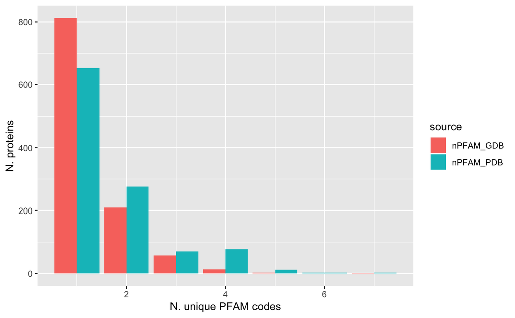

```r
ggsave("../results/F2c.pdf",width=5,height=4)
```

# Random forest classifier

## Train classifier

Create training and test data

```r
Gd_forRF <- metrics_nMatch %>% select(1,TM:RMSD_model_sd,lenRatio,SS_sd,matchStatus) %>% na.omit()
#Gd_forRF %>% str()

geneOrder <- read_tsv("../data/Gd_forRF_geneIDorder.tsv")
Gd_forRF <- geneOrder %>% left_join(Gd_forRF, by="GeneID")  #original geneOrder
set.seed(1234) ; forTRAIN_exact <- Gd_forRF %>% filter(matchStatus=="exactMatch") %>%  sample_n(750);
set.seed(1234) ; forTRAIN_noMatch <- Gd_forRF %>% filter(matchStatus!="exactMatch") %>%  sample_n(750);
forTRAIN <- rbind(forTRAIN_exact, forTRAIN_noMatch)
#set.seed(1234); TEST <- Gd_forRF %>% anti_join(forTRAIN, by="GeneID") %>% sample_n(1500) ;
set.seed(4321); forTEST_exact <- Gd_forRF %>% anti_join(forTRAIN_exact, by="GeneID") %>% filter(matchStatus=="exactMatch") %>% sample_n(250)

set.seed(4321); forTEST_noMatch <- Gd_forRF %>% anti_join(forTRAIN_noMatch, by="GeneID") %>% filter(matchStatus!="exactMatch") %>% sample_n(250)
TEST <- rbind(forTEST_exact, forTEST_noMatch)
TRAIN <- forTRAIN %>% dplyr::select(-c(GeneID))
```

Model training is only run once.

```r
rf_model <- train(matchStatus ~. , data=TRAIN, method="rf",
                  trControl = trainControl(method="cv", number=5, verboseIter=TRUE),
                  prox=TRUE, verbose=TRUE)
saveRDS(rf_model,"../data/rf_model.Rds")
```

Print final model

```r
rf_model <- readRDS("../data/rf_model.Rds")
print(rf_model$finalModel)
```

```
Call:
 randomForest(x = x, y = y, mtry = param$mtry, proximity = TRUE,      verbose = TRUE)
               Type of random forest: classification
                     Number of trees: 500
No. of variables tried at each split: 2

        OOB estimate of  error rate: 9.93%
Confusion matrix:
           exactMatch noMatch class.error
exactMatch        694      56  0.07466667
noMatch            93     657  0.12400000
```

## Classifier performance

```r
predTEST <- predict(rf_model, newdata=TEST, type="prob")
predALL <- predict(rf_model, newdata=Gd_forRF, type="prob")
#summary(predTEST)
#summary(predALL)
#accuracy on hold-out TEST set:
TEST %>%  mutate(RFexact_pred = predTEST$exactMatch) %>%
  mutate(predStatus=ifelse(RFexact_pred >= 0.5,"exactMatch","noMatch")) %>%
  count(matchStatus, predStatus)
```

| matchStatus | predStatus | n |
| --- | --- | --- |
| exactMatch | exactMatch | 228 |
| exactMatch | noMatch | 22 |
| noMatch | exactMatch | 24 |
| noMatch | noMatch | 226 |

```r
#entire proteome
Gd_forRF %>% mutate(RFexact_pred = predALL$exactMatch) %>%
  mutate(predStatus=ifelse(RFexact_pred >= 0.5,"exactMatch","noMatch")) %>%
  count(matchStatus, predStatus)
```

| matchStatus | predStatus | n |
| --- | --- | --- |
| exactMatch | exactMatch | 1054 |
| exactMatch | noMatch | 34 |
| noMatch | exactMatch | 305 |
| noMatch | noMatch | 3437 |

```r
Gd_matchPredict <- Gd_forRF %>% mutate(exactMatchPred = predALL$exactMatch) %>% ungroup()
```

## Fig 3a

### Compute feature importance

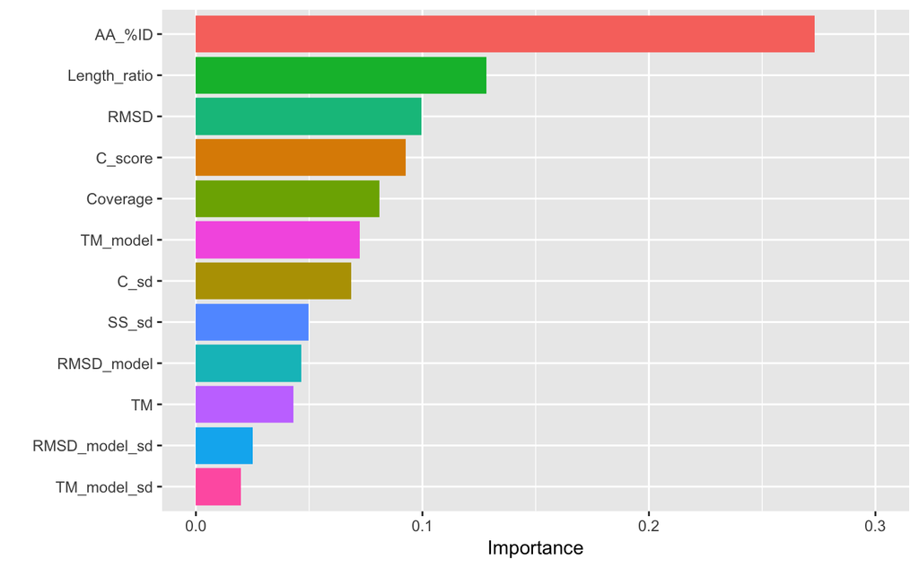

```r
Gd_imp <- data.frame(varImp(rf_model, scale=FALSE)$importance)
Gd_imp$noi  <- row.names(Gd_imp); row.names(Gd_imp) <- NULL
names(Gd_imp) <- c('Contribn', 'impFactor') ; #head(Gd_imp)
Gd_imp <- Gd_imp %>%dplyr::select(2,1) %>% arrange(desc(Contribn)) %>%  mutate(propCont = Contribn/sum(Contribn))
imp_plot <- Gd_imp %>%
  mutate(impFactor_recode = case_when(impFactor=="AApc" ~ 'AA_%ID',
                               impFactor=="Cscore" ~ 'C_score',
                               impFactor=="AApc" ~ "AA_%ID",
                               impFactor=="Cov" ~ 'Coverage',
                               impFactor=="exactMatchPred" ~ 'Exact_match_prediction',
                               impFactor=="lenRatio" ~ 'Length_ratio',
                               TRUE ~ impFactor)) %>%
  ggplot(aes(x=reorder(impFactor_recode, propCont), y=propCont)) +
  geom_bar(stat="identity", aes(fill=impFactor_recode), show.legend = FALSE) +
  ylab("Importance") + xlab("") + ylim(0,0.3) +
  coord_flip()
imp_plot
ggsave("../results/SF3a.pdf",imp_plot, width=4,height=3)
```

## Fig 3b

### Sensitivity and specificity

```r
##AUROC
#https://gist.github.com/jwaage/6d8f4eb096e4f18a0894ca1ce27af834
forROC <- Gd_matchPredict %>%
  dplyr::select(TM:exactMatchPred) %>%
  mutate(matchStatus = abs(as.numeric(factor(matchStatus))-2))
aucOut <- data_frame('sensPlt' = NA, 'specPlt' = NA, 'Metric'=NA,'AUC' = NA)
for (i in names(forROC)){#print(i)
  r <- roc(forROC$matchStatus, forROC[ , i] %>% pull())
  sens <- r$sensitivities
  spec <- r$specificities
  a <- auc(r)[1]
  rnd <- round(a,3)
  result <- data_frame('sensPlt' = rev(sens), 'specPlt' = rev(spec)) %>% mutate(Metric = i, AUC = rnd)
  aucOut <- rbind(aucOut,result) %>% na.omit() }
auc_plot <- aucOut %>%  mutate(Metric = case_when(Metric=="AApc" ~ 'AA_%ID',
                               Metric=="Cscore" ~ 'C_score',
                               Metric=="AApc" ~ "AA_%ID",
                               Metric=="Cov" ~ 'Coverage',
                               Metric=="exactMatchPred" ~ 'Exact_match_prediction',
                               Metric=="lenRatio" ~ 'AA_length_ratio',
                               TRUE ~ Metric)) %>%
  filter(Metric !="matchStatus") %>%
  distinct() %>% na.omit() %>% filter(AUC >= 0.7) %>%
  ggplot(aes(x=specPlt,y=sensPlt)) +
  geom_segment(aes(x = 0, y = 1, xend = 1, yend = 0), alpha = 0.5) +
  geom_step(aes(col=Metric), lty = 2,lwd=1) +
  scale_x_reverse(name = "False positive rate (Specificity)",limits = c(1,0)) +
  ylab("True positive rate (Sensitivity)") +
  coord_equal() +
  scale_color_manual(values= c("AA_%ID" = "#F8766D","C_score" = "#DE8C00",
                               "Exact_match_prediction" = 'black','AA_length_ratio' = "#00BA38",
                               "RMSD" = "#00BFC4","TM_model" = "#F564E3"))
aucOut %>% select(-contains('Plt')) %>% distinct() %>% arrange(desc(AUC))
```

| Metric | AUC |
| --- | --- |
| matchStatus | 1.000 |
| exactMatchPred | 0.977 |
| AApc | 0.923 |
| lenRatio | 0.824 |
| RMSD | 0.811 |
| Cscore | 0.725 |
| TM_model | 0.725 |
| Cov | 0.695 |
| SS_sd | 0.673 |
| RMSD_model | 0.630 |

[output cut: 4 more lines]

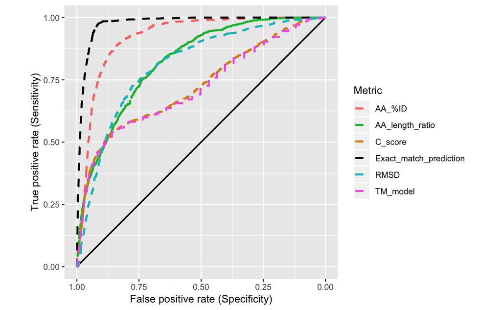

```r
auc_plot
ggsave("../results/F3b.pdf",auc_plot, width=5,height=5)
```

## Test classifier on models from Human

| matchStatus | pred_matchStatus | n | gpErr |
| --- | --- | --- | --- |
| IPRexact | exact | 43 | 0.95555556 |
| IPRexact | noMatch | 2 | 0.04444444 |
| nomatch | exact | 9 | 0.16363636 |
| nomatch | noMatch | 46 | 0.83636364 |

## Metric distribution by RF confidence

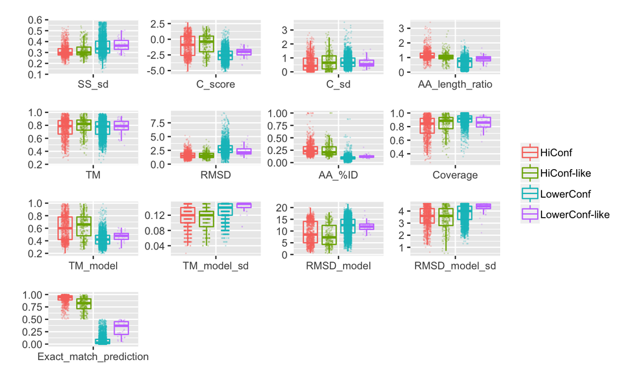

```r
Gd_all <- metrics_nMatch %>% left_join(Gd_matchPredict %>% dplyr::select(1,exactMatchPred),by="GeneID")
Gd_all_RFconf <- Gd_all %>%
  mutate(RF_confidence = case_when(matchStatus=="exactMatch" & exactMatchPred >= 0.5 ~ 'HiConf',
                                matchStatus=="noMatch" & exactMatchPred < 0.5        ~ 'LowerConf',
                                matchStatus=="exactMatch" & exactMatchPred < 0.5     ~ "LowerConf-like",
                                matchStatus=="noMatch" & exactMatchPred >= 0.5       ~ "HiConf-like",
                                TRUE ~ ""))
Gd_all_RFconf %>% select(TM:RMSD_model_sd,lenRatio,SS_sd,matchStatus,exactMatchPred,RF_confidence) %>%
  rename(Exact_match_prediction = exactMatchPred, AA_length_ratio = lenRatio,
         `AA_%ID` = AApc, Coverage = Cov, C_score = Cscore) %>%
  filter(C_score > -8 & RMSD_model < 25) %>%
  gather(key,value,-c(RF_confidence,matchStatus)) %>%
  filter(str_detect(RF_confidence,"Conf")) %>%
  na.omit() %>%
  mutate(key = fct_relevel(factor(key), c('SS_sd', 'C_score','C_sd', 'AA_length_ratio',
                                          'TM','RMSD','AA_%ID','Coverage',
                                          'TM_model','TM_model_sd','RMSD_model','RMSD_model_sd',
                                          'Exact_match_prediction'))) %>%
  ggplot(aes(x=key, y=value, col=RF_confidence)) +
  geom_point(position=position_jitterdodge(jitter.width = 0.1, dodge.width=1),
             size=0.02, alpha=0.2, show.legend = TRUE) +
  geom_boxplot( position=position_dodge(1), alpha=0) +
  xlab("") + ylab("") +
  theme(legend.title=element_blank(),
        strip.background = element_blank(),
        strip.text.x = element_text(size=0)) +
  facet_wrap( ~ key, scales="free")
ggsave("../results/F4.pdf",width=9.5,height=9)
```

## SFigure 4a

Technical variation: Train 500 models on the same data.

```r
RF_train_iter500 <- data_frame('dummy'=rep(NA, nrow(Gd_forRF)))
for(i in 1:500){

  a <- train(matchStatus ~. , data=TRAIN, method="rf",
             trControl = trainControl(method="cv", number=5, verboseIter=TRUE),
             prox=TRUE, verbose=TRUE)

  fm <- as_data_frame(predict(a, newdata = Gd_forRF, type="prob"))
  fm <- fm[ , 1]
  names(fm) <- paste0('rf_',i)
  RF_train_iter500 <- cbind(RF_train_iter500, fm)

}

RF_train_iter500 <- RF_train_iter500[ , -1]

saveRDS(RF_train_iter500, "../data/RF_train_iter500.Rds")
```

Plot technical variation

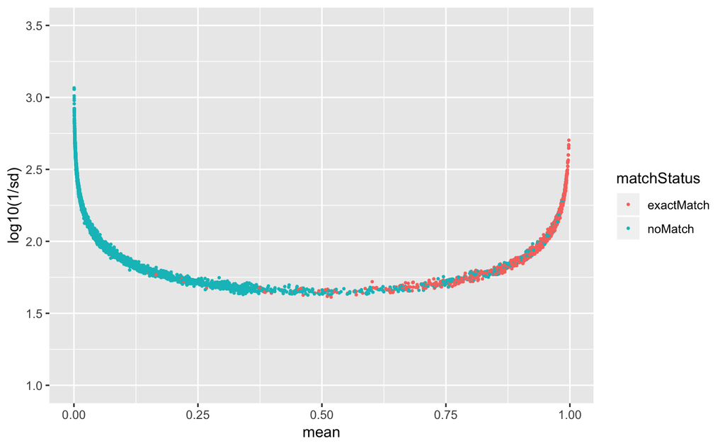

```r
RF_train_iter500 <- readRDS("../data/RF_train_iter500.Rds")
RF_train_iter500_summary <- data_frame('mean' = rowMeans(RF_train_iter500),
                      'sd' = apply(RF_train_iter500 ,1, sd, na.rm = TRUE),
                      'sem' = apply(RF_train_iter500 , 1, function(x) sd(x)/sqrt(length(x))),
                      'len' = apply(RF_train_iter500 , 1, length ))
RF_train_iter500_summary %>% cbind(Gd_forRF) %>% dplyr::select(mean,sd,sem,matchStatus) %>%
  ggplot(aes(mean, log10(1/sd))) + geom_point(aes(col=matchStatus), cex=0.5) +
  ylim(1,3.5)
ggsave("../results/SF6a.pdf",width=5,height=4)
```

## SFigure 4b

Robustness: Train 50 models on different training data and set sizes

```r
RF_sample_iter500 <- data_frame("GeneID" = Gd_forRF %>% select(GeneID) %>% pull())

for(i in c(50,100,200,300,400,500)){
  for(j in 1:50){
    sample_iterTrain <- rbind(Gd_forRF %>% filter(matchStatus=='noMatch') %>% sample_n(i),
                       Gd_forRF %>% filter(matchStatus=='exactMatch') %>% sample_n(i))

    rfMod_iter <- train(matchStatus ~ . , data = sample_iterTrain %>% select(-GeneID), method="rf",
                        trControl = trainControl(method="cv", number=5, verboseIter=TRUE),
                        prox=TRUE, verbose=TRUE)
    fm_t <- as_data_frame(predict(rfMod_iter, newdata=Gd_forRF, type="prob"))
    fm_t <- fm_t[ , 1]
    names(fm_t) <- paste('rf_train', 2*i, 'iter', j, sep="_")
    RF_sample_iter500 <- cbind(RF_sample_iter500, fm_t)
  }
}

saveRDS(RF_sample_iter500, "../data/RF_sample_iter500.Rds")
```

Plot reproducibility

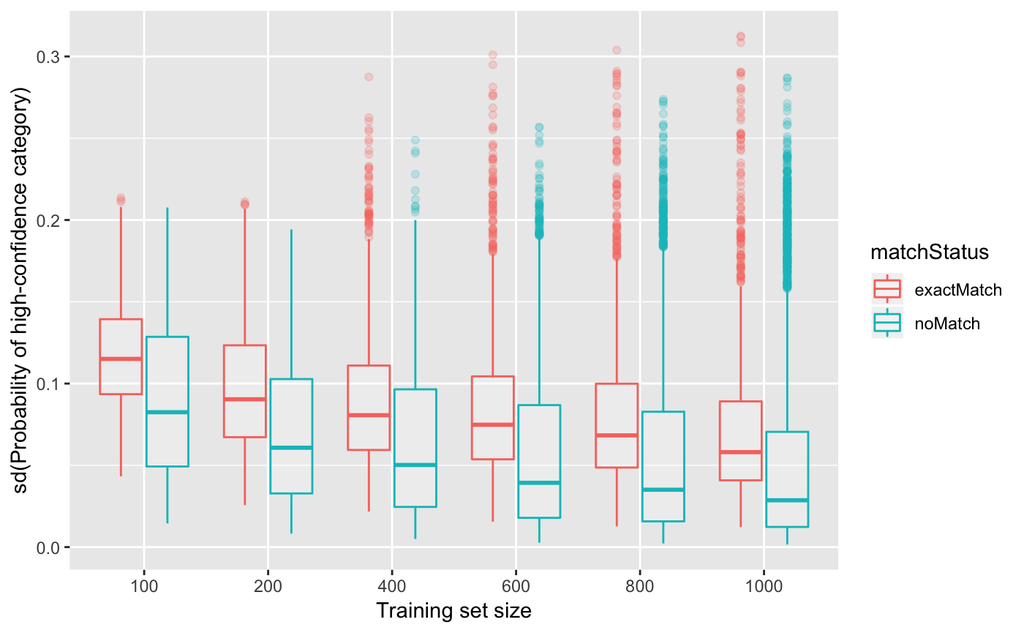

```r
RF_sample_iter500 <- readRDS("../data/RF_sample_iter500.Rds")
RF_sample_iter500 %>%
  gather(key,value,-GeneID) %>%
  separate(key,into=c("v1","v2","v3","v4","v5"),sep="_",convert = TRUE) %>%
  select(GeneID,v3,v5,value) %>% dplyr::rename(trainingSetSize=v3,iteration=v5) %>%
  group_by(GeneID,trainingSetSize) %>% summarize(mean=mean(value),sd=sd(value)) %>%
  left_join(Gd_forRF %>% select(GeneID,matchStatus),by="GeneID") %>%
  ggplot(aes(x=factor(trainingSetSize),y=sd)) +
  geom_boxplot(alpha=0.2, aes(col=matchStatus )) +
  xlab('Training set size') + ylab("sd(Probability of high-confidence category)")
ggsave("../results/SF6b.pdf",width=7,height=4)
```

## SFigure 4c

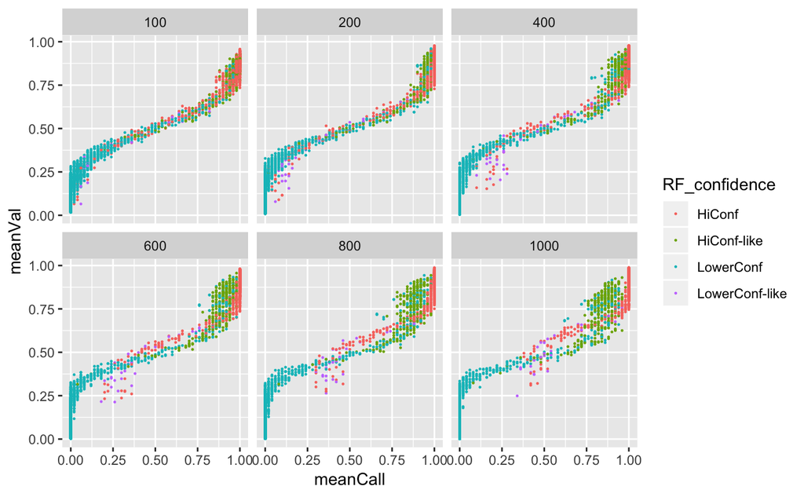

```r
RF_sample_iter500 %>%
  gather(key,value,-GeneID) %>%
  separate(key,into=c("v1","v2","v3","v4","v5"),sep="_",convert = TRUE) %>%
  select(GeneID,v3,v5,value) %>%
  dplyr::rename(trainingSetSize=v3,iteration=v5) %>%
  group_by(GeneID,trainingSetSize) %>%
  mutate(call=ifelse(value>0.5,1,0)) %>%
  group_by(GeneID,trainingSetSize) %>%
  mutate(meanCall=mean(call), meanVal=mean(value),
         sdCall=sd(call), sdVal=sd(value)) %>%
  ungroup() %>%
  select(-c(value,iteration,call)) %>% distinct() %>%
  left_join(Gd_forRF %>% select(GeneID, matchStatus),by="GeneID") %>%
  left_join(Gd_all_RFconf %>% select(GeneID,exactMatchPred,RF_confidence),
            by="GeneID") %>% filter(RF_confidence!="") %>%
  ggplot(aes(x=meanCall,y=meanVal)) +
  geom_point(aes(col=RF_confidence),cex=0.2) +
  facet_wrap(~ trainingSetSize)
ggsave("../results/SF6c.pdf",width=8,height=4)
```

## Features of lower conf-like models?

```r
Gd_all_RFconf %>% filter(RF_confidence=="LowerConf-like") %>%
  left_join(metrics_long,by="GeneID") %>%
  filter(PDB_PFAMpref== GDB_PFAMpref) %>%
  select(GeneID,GDB_PFAMpref) %>%
  distinct() %>%
  left_join(PFAM_descriptionTable,by=c('GDB_PFAMpref' = 'PFAMcode')) %>%
  count(desc) %>% arrange(desc(n)) %>% filter(n>1)
```

| desc | n |
| --- | --- |
| Protein kinase domain | 13 |
| Ankyrin repeats (3 copies) | 5 |
| Zinc finger, C3HC4 type (RING finger) | 2 |

```r
Gd_all_RFconf %>% filter(RF_confidence=="LowerConf") %>%
  left_join(metrics_long,by="GeneID") %>%
  select(GeneID,GDB_PFAMpref) %>%
  na.omit() %>%
  distinct() %>%
  left_join(PFAM_descriptionTable,by=c('GDB_PFAMpref' = 'PFAMcode')) %>%
  count(desc) %>% arrange(desc(n)) %>% filter(n>5)
```

| desc | n |
| --- | --- |
| Protein kinase domain | 39 |
| Ankyrin repeats (3 copies) | 38 |
| Protein of unknown function (DUF3070) | 29 |
| Tetratricopeptide repeat | 12 |
| Transmembrane amino acid transporter protein | 11 |
| TPR repeat | 9 |
| DHHC palmitoyltransferase | 8 |
| ABC transporter | 7 |
| ATPase family associated with various cellular activities (AAA) | 7 |
| EGF-like domain | 7 |

[output cut: 8 more lines]

## Compute relative abundance of domains across confidence groups

```r
Gd_all_RFconf %>%
  left_join(metrics_long,by="GeneID") %>%
  select(GeneID,GDB_PFAMpref,PDB_PFAMpref, RF_confidence) %>%distinct() %>%
  gather(key,value,-c(GeneID,RF_confidence)) %>%
  distinct() %>% ungroup() %>%
  filter(RF_confidence!="") %>% na.omit() %>%
  group_by(RF_confidence,key) %>% count(value) %>%
  spread(RF_confidence,n, fill = 0) %>%
  filter(key=="GDB_PFAMpref") %>%
  rowwise() %>%
  mutate(ratio = (LowerConf /1389) / (sum(`HiConf`,`HiConf-like`,`LowerConf-like`) / 1389)) %>%
  filter(LowerConf>0, ratio!="Inf") %>%
  arrange(desc(ratio)) %>%
  left_join(PFAM_descriptionTable,by=c('value'='PFAMcode')) %>%
  select(desc,ratio, everything())
```

| desc | ratio | key | value | HiConf | HiConf-like | LowerConf | LowerConf-like |
| --- | --- | --- | --- | --- | --- | --- | --- |
| Galactose oxidase, central domain | 6.00000000 | GDB_PFAMpref | PF13418 | 0 | 1 | 6 | 0 |
| Dynein heavy chain and region D6 of dynein motor | 5.00000000 | GDB_PFAMpref | PF03028 | 1 | 0 | 5 | 0 |
| Tubulin C-terminal domain | 5.00000000 | GDB_PFAMpref | PF03953 | 1 | 0 | 5 | 0 |
| Brix domain | 4.00000000 | GDB_PFAMpref | PF04427 | 0 | 1 | 4 | 0 |
| Leucine-rich repeat | 4.00000000 | GDB_PFAMpref | PF14580 | 0 | 1 | 4 | 0 |
| Dpy-30 motif | 3.00000000 | GDB_PFAMpref | PF05186 | 1 | 0 | 3 | 0 |
| Tetratricopeptide repeat | 3.00000000 | GDB_PFAMpref | PF07719 | 1 | 0 | 3 | 0 |
| Myb-like DNA-binding domain | 2.00000000 | GDB_PFAMpref | PF00249 | 1 | 0 | 4 | 1 |
| XPG N-terminal domain | 2.00000000 | GDB_PFAMpref | PF00752 | 1 | 0 | 2 | 0 |
| XPG I-region | 2.00000000 | GDB_PFAMpref | PF00867 | 1 | 0 | 2 | 0 |

[output cut: 112 more lines]

```r
NA
NA
NA
```

# Clustering analysis

## SFigure 5

Compare sequence- and structure-based clusters

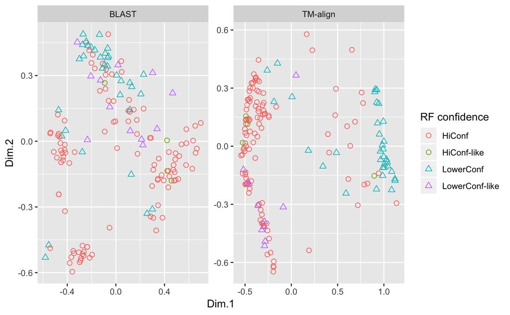

```r
blst_Nek <- read_tsv("../data/Nek_kinase_BLASTp.tsv", col_names = TRUE)
TM_Nek <- read_tsv("../data/Nek_kinase_TM.tsv", col_names = TRUE)
blst_matFull <- blst_Nek %>% mutate(value=percent_rank(bit_score)) %>%
  select(query_id,subject_id,value) %>%
  spread(subject_id,value, fill = 0) %>% select(-query_id) %>% as.matrix()
rownames(blst_matFull) <- colnames(blst_matFull)
TM_matFull <- TM_Nek %>% spread(struc2,TM, fill=0) %>% select(-struc1) %>% as.matrix()
rownames(TM_matFull) <- colnames(TM_matFull)
blst_TM_mds <- rbind((1-cor(blst_matFull)) %>%
                       cmdscale() %>%
                       as_tibble() %>%
                       mutate(dtype="blst"),
                     (1-cor(TM_matFull)) %>%
                       cmdscale() %>%
                       as_tibble() %>%
                       mutate(dtype="TM")) %>%
  dplyr::rename(Dim.1 = V1, Dim.2 = V2) %>%
  mutate(GeneID=str_replace(rep(rownames(blst_matFull),2),"GL_","GL50803_"))
blst_TM_mds %>%
  left_join(Gd_all_RFconf, by="GeneID") %>%
  mutate(dtype=recode(dtype,blst="BLAST",TM="TM-align")) %>%
  filter(!is.na(RF_confidence)) %>%
  dplyr::rename("RF confidence" = RF_confidence) %>%
  ggplot(aes(x=Dim.1,y=Dim.2 )) +
  geom_point(aes(col=`RF confidence`, shape=`RF confidence`), size=2) +
  scale_shape_manual(values=c('HiConf'=1,'HiConf-like' = 1, 'LowerConf' =2, "LowerConf-like" = 2)) +
  facet_wrap(~ dtype , scales="free")
ggsave("../results/SF7.pdf",width=9,height=4)
```

# Transcriptional abundance

## SFigure 6

Transcriptional abundance by RF confidence

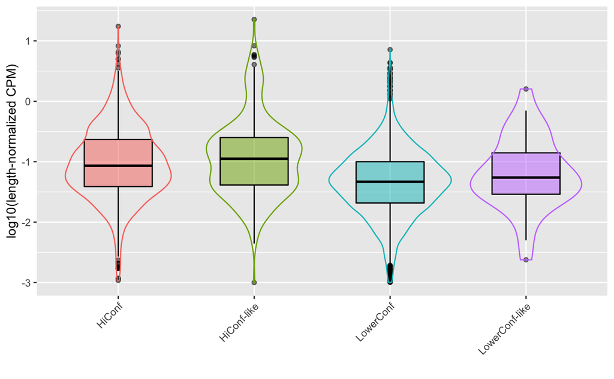

```r
transcription_cpm <- read_tsv("../data/Ansell_2017_GiardiaCPM.tsv", col_types = cols())
transc_by_category <- Gd_all_RFconf %>%
   mutate(transcriptLen=(GDB_AA * 3) - 3) %>%
   left_join(transcription_cpm,by="GeneID") %>%
   select(GeneID,RF_confidence,transcriptLen,contains('-s')) %>%
   gather(key,value,-c(GeneID,transcriptLen,RF_confidence)) %>%
   mutate(value=ifelse(is.na(value),0.1,value)) %>%
   mutate(value=value/transcriptLen) %>% na.omit() %>%
   group_by(GeneID,RF_confidence) %>% summarize(meanVal=mean(value)) %>%
  filter(!RF_confidence=="")

transc_by_category %>%
   filter(meanVal > 0.001) %>%
   ggplot(aes(x=RF_confidence,y=log10(meanVal))) +
   geom_boxplot(aes(fill=RF_confidence), width=0.5, col="black", alpha=0.5) +
   geom_violin(aes(col=RF_confidence), alpha=0) +
   theme(legend.position="none") +
   theme(axis.text.x=element_text(angle=45, hjust=1)) +
   xlab("") + ylab("log10(length-normalized CPM)")
ggsave("../results/SF8.pdf",width=4,height=4)
```

```r
#Test differences
aov_transc.res <- aov(meanVal ~ RF_confidence,
                      data=transc_by_category %>% filter(meanVal> 0.001))
summary(aov_transc.res)
```

```
                Df Sum Sq Mean Sq F value Pr(>F)
RF_confidence    3   50.3  16.754   42.42 <2e-16 ***
Residuals     4343 1715.3   0.395
---
Signif. codes:  0 ‘***’ 0.001 ‘**’ 0.01 ‘*’ 0.05 ‘.’ 0.1 ‘ ’ 1
```

```r
TukeyHSD(aov_transc.res)
```

```
  Tukey multiple comparisons of means
    95% family-wise confidence level

Fit: aov(formula = meanVal ~ RF_confidence, data = transc_by_category %>% filter(meanVal > 0.001))

$RF_confidence
                                  diff        lwr         upr     p adj
HiConf-like-HiConf          0.20759312  0.1019366  0.31324968 0.0000028
LowerConf-HiConf           -0.16190156 -0.2199994 -0.10380374 0.0000000
LowerConf-like-HiConf      -0.10677903 -0.3923471  0.17878900 0.7716333
LowerConf-HiConf-like      -0.36949468 -0.4671976 -0.27179175 0.0000000
LowerConf-like-HiConf-like -0.31437215 -0.6105471 -0.01819719 0.0324399
LowerConf-like-LowerConf    0.05512253 -0.2275993  0.33784440 0.9588284
```

# Supplementary Tables

Write supplementary Tables

```r
write_tsv(Gd_all_RFconf %>%
            select(-c(seq.ssLen,
                      nHrc,nErc,nCrc,
                      strucSum,strpPDB_AA, codechain)) %>%
                     dplyr::rename(Exact_match_prediction =exactMatchPred,
                Length_ratio=lenRatio,Match_status=matchStatus,`AA_%ID`=AApc,
                C_score=Cscore,
                Annot_status=descBin,Confidence_category =RF_confidence) %>%
            arrange(desc(C_score,Confidence_category)),
            path="../results/STable_2.tsv")
write_tsv(Gd_all_RFconf %>%
            select(-c(seq.ssLen,
                      nHrc,nErc,nCrc,
                      strucSum,strpPDB_AA, codechain)) %>%
            filter(RF_confidence=="HiConf-like" & descBin=="Hyp") %>%
            dplyr::rename(Exact_match_prediction =exactMatchPred,
                Length_ratio=lenRatio,Match_status=matchStatus,`AA_%ID`=AApc,
                C_score=Cscore,
                Annot_status=descBin,Confidence_category =RF_confidence) %>%
              arrange(desc(C_score,Confidence_category)),
          path="../results/STable_3.tsv")
```

# RF clasifier sans %AA ID

RF classifier without AA_%ID

```r
TRAIN_nopcAA <- forTRAIN %>% dplyr::select(-c(GeneID,AApc))

rf_model_nopcAA <- train(matchStatus ~. , data=TRAIN_nopcAA, method="rf",
                  trControl = trainControl(method="cv", number=5, verboseIter=FALSE),
                  prox=TRUE, verbose=FALSE)
saveRDS(rf_model_nopcAA, "../data/rf_model_nopcAA.Rds")
```

```r
rf_model_nopcAA <- readRDS("../data/rf_model_nopcAA.Rds")
print(rf_model_nopcAA$finalModel)
```

```
Call:
 randomForest(x = x, y = y, mtry = param$mtry, proximity = TRUE,      verbose = FALSE)
               Type of random forest: classification
                     Number of trees: 500
No. of variables tried at each split: 2

        OOB estimate of  error rate: 11%
Confusion matrix:
           exactMatch noMatch class.error
exactMatch        683      67  0.08933333
noMatch            98     652  0.13066667
```

Classifier performance without % AA ID.

```r
predTEST_nopcAA <- predict(rf_model_nopcAA, newdata=TEST, type="prob")
predALL_nopcAA <- predict(rf_model_nopcAA, newdata=Gd_forRF, type="prob")
# summary(predTEST_nopcAA)
# summary(predALL_nopcAA)
#accuracy on hold-out TEST set:
TEST %>%  mutate(RFexact_pred_nopcAA = predTEST_nopcAA$exactMatch) %>%
  mutate(predStatus=ifelse(RFexact_pred_nopcAA > 0.5,"exactMatch","noMatch")) %>%
  count(matchStatus, predStatus) %>%
  group_by(matchStatus) %>% mutate(gpErr=n/sum(n))
```

| matchStatus | predStatus | n | gpErr |
| --- | --- | --- | --- |
| exactMatch | exactMatch | 227 | 0.908 |
| exactMatch | noMatch | 23 | 0.092 |
| noMatch | exactMatch | 29 | 0.116 |
| noMatch | noMatch | 221 | 0.884 |

```r
#entire proteome
Gd_forRF %>% mutate(RFexact_pred_nopcAA = predALL_nopcAA$exactMatch) %>%
  mutate(predStatus=ifelse(RFexact_pred_nopcAA > 0.5,"exactMatch","noMatch")) %>%
  count(matchStatus, predStatus) %>%
  group_by(matchStatus) %>% mutate(gpErr=n/sum(n))
```

| matchStatus | predStatus | n | gpErr |
| --- | --- | --- | --- |
| exactMatch | exactMatch | 1048 | 0.96323529 |
| exactMatch | noMatch | 40 | 0.03676471 |
| noMatch | exactMatch | 349 | 0.09326563 |
| noMatch | noMatch | 3393 | 0.90673437 |

Compute feature importance and predictive power

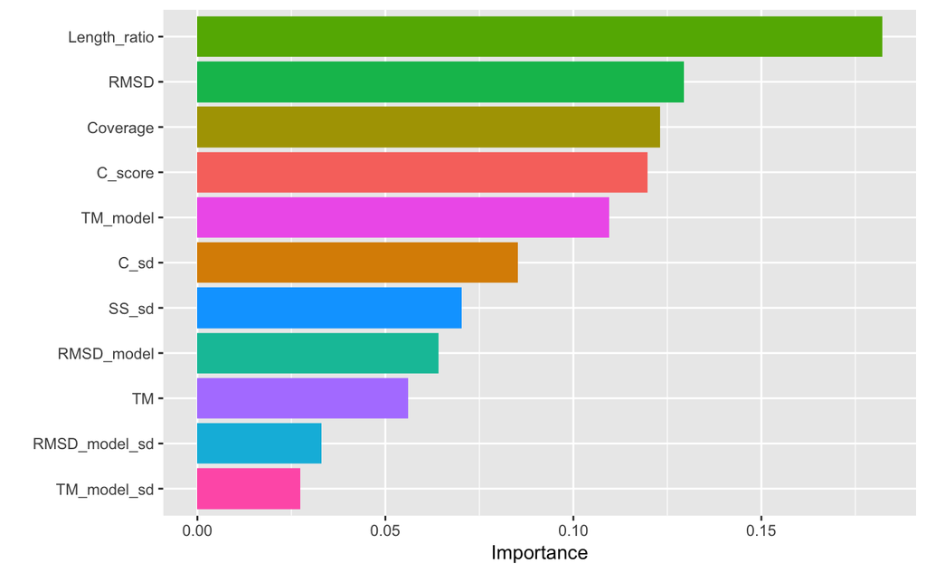

```r
Gd_imp_nopcAA <- data.frame(varImp(rf_model_nopcAA, scale=FALSE)$importance)
Gd_imp_nopcAA$noi  <- row.names(Gd_imp_nopcAA); row.names(Gd_imp_nopcAA) <- NULL
names(Gd_imp_nopcAA) <- c('Contribn', 'impFactor')
Gd_imp_nopcAA <- Gd_imp_nopcAA %>%dplyr::select(2,1) %>%
  arrange(desc(Contribn)) %>%  mutate(propCont = Contribn/sum(Contribn))
imp_plot_nopcAA <- Gd_imp_nopcAA %>%
  mutate(impFactor_recode = case_when(impFactor=="Cscore" ~ 'C_score',
                               impFactor=="Cov" ~ 'Coverage',
                               impFactor=="exactMatchPred" ~ 'Exact_match_prediction',
                               impFactor=="lenRatio" ~ 'Length_ratio',
                               TRUE ~ impFactor)) %>%
  ggplot(aes(x=reorder(impFactor_recode, propCont), y=propCont)) +
  geom_bar(stat="identity", aes(fill=impFactor_recode), show.legend = FALSE) +
  ylab("Importance") + xlab("") +
  coord_flip()
imp_plot_nopcAA
ggsave("../results/SF5.pdf", imp_plot_nopcAA, width=4,height=3)
```